# BikeShare

For fun, let’s build a few quick multiple regression models to predict number of riders. Since we’ve see that casual and registered riders are quite different, we’ll build models specific to a given population. Notice that we’ve included a mix of categorical and continuous variables. R automatically takes care of the conversion of categorical variables to sets of appropriate binary indicator variables.

```r
lm1 <- lm(registered ~ dayofweek + hour + year, data = train)
summary(lm1)
```

```
##
## Call:
## lm(formula = registered ~ dayofweek + hour + year, data = train)
##
## Residuals:
##     Min      1Q  Median      3Q     Max
## -361.28  -57.82   -5.15   44.69  464.98
##
## Coefficients:
##              Estimate Std. Error t value Pr(>|t|)
## (Intercept)  154.7962     0.9427 164.202  < 2e-16 ***
## dayofweek.L   12.5112     2.4878   5.029 5.01e-07 ***
## dayofweek.Q  -43.3461     2.4855 -17.439  < 2e-16 ***
## dayofweek.C   -1.2616     2.4938  -0.506  0.61295
## dayofweek^4  -16.4192     2.5009  -6.565 5.42e-11 ***
## dayofweek^5    0.9925     2.5002   0.397  0.69139
## dayofweek^6    2.0889     2.4975   0.836  0.40295
## hour.L       228.5088     4.6181  49.481  < 2e-16 ***
## hour.Q      -316.9638     4.6181 -68.635  < 2e-16 ***
## hour.C      -150.6438     4.6181 -32.620  < 2e-16 ***
## hour^4       -50.3937     4.6181 -10.912  < 2e-16 ***
## hour^5       -58.7876     4.6181 -12.730  < 2e-16 ***
## hour^6       186.5437     4.6181  40.394  < 2e-16 ***
## hour^7        88.8997     4.6181  19.250  < 2e-16 ***
## hour^8      -140.4214     4.6181 -30.407  < 2e-16 ***
## hour^9       -35.7419     4.6181  -7.739 1.09e-14 ***
## hour^10        9.6693     4.6181   2.094  0.03630 *
## hour^11      -29.4821     4.6181  -6.384 1.80e-10 ***
## hour^12       87.2230     4.6181  18.887  < 2e-16 ***
## hour^13       54.4735     4.6181  11.796  < 2e-16 ***
## hour^14      -90.3875     4.6181 -19.572  < 2e-16 ***
## hour^15      -28.2884     4.6181  -6.126 9.35e-10 ***
## hour^16       38.3071     4.6181   8.295  < 2e-16 ***
## hour^17       -9.5522     4.6181  -2.068  0.03862 *
## hour^18       13.9395     4.6181   3.018  0.00255 **
## hour^19       21.8987     4.6181   4.742 2.14e-06 ***
## hour^20      -21.9742     4.6181  -4.758 1.98e-06 ***
## hour^21       -2.1989     4.6181  -0.476  0.63398
## hour^22      -10.4015     4.6181  -2.252  0.02432 *
## hour^23        0.7065     4.6181   0.153  0.87841
## year.L        57.0637     1.3335  42.793  < 2e-16 ***
## ---
## Signif. codes:  0 '***' 0.001 '**' 0.01 '*' 0.05 '.' 0.1 ' ' 1
##
## Residual standard error: 98.62 on 10913 degrees of freedom
## Multiple R-squared:  0.5753, Adjusted R-squared:  0.5742
## F-statistic: 492.8 on 30 and 10913 DF,  p-value: < 2.2e-16
```

```r
lm2 <- lm(registered ~ dayofweek + hour + year + weather + season + atemp, data = train)
summary(lm2)
```

```
##
## Call:
## lm(formula = registered ~ dayofweek + hour + year + weather +
##     season + atemp, data = train)
##
## Residuals:
##     Min      1Q  Median      3Q     Max
## -287.12  -56.76   -8.35   46.54  430.54
##
## Coefficients:
##              Estimate Std. Error t value Pr(>|t|)
## (Intercept)   62.5970     3.2457  19.286  < 2e-16 ***
## dayofweek.L   14.8439     2.2820   6.505 8.13e-11 ***
## dayofweek.Q  -45.0059     2.2850 -19.696  < 2e-16 ***
## dayofweek.C   -1.8629     2.2930  -0.812 0.416545
## dayofweek^4  -12.7666     2.2989  -5.553 2.87e-08 ***
## dayofweek^5   -0.8448     2.2979  -0.368 0.713169
## dayofweek^6    1.2123     2.2940   0.528 0.597180
## hour.L       214.1658     4.3555  49.172  < 2e-16 ***
## hour.Q      -302.8107     4.3394 -69.782  < 2e-16 ***
## hour.C      -134.0550     4.3456 -30.849  < 2e-16 ***
## hour^4       -56.3941     4.2752 -13.191  < 2e-16 ***
## hour^5       -64.6798     4.2583 -15.189  < 2e-16 ***
## hour^6       191.6734     4.2429  45.175  < 2e-16 ***
## hour^7        90.8160     4.2379  21.429  < 2e-16 ***
## hour^8      -143.2671     4.2401 -33.789  < 2e-16 ***
## hour^9       -34.4320     4.2386  -8.123 5.03e-16 ***
## hour^10        8.6765     4.2367   2.048 0.040593 *
## hour^11      -30.0611     4.2351  -7.098 1.34e-12 ***
## hour^12       88.4404     4.2364  20.876  < 2e-16 ***
## hour^13       53.5393     4.2400  12.627  < 2e-16 ***
## hour^14      -90.2914     4.2424 -21.283  < 2e-16 ***
## hour^15      -28.6261     4.2419  -6.748 1.57e-11 ***
## hour^16       38.3965     4.2394   9.057  < 2e-16 ***
## hour^17       -8.5191     4.2366  -2.011 0.044365 *
## hour^18       14.2803     4.2318   3.375 0.000742 ***
## hour^19       22.2749     4.2281   5.268 1.40e-07 ***
## hour^20      -22.1482     4.2257  -5.241 1.62e-07 ***
## hour^21       -3.2070     4.2248  -0.759 0.447813
## hour^22      -10.7585     4.2239  -2.547 0.010878 *
## hour^23        0.5602     4.2245   0.133 0.894504
## year.L        54.6742     1.2308  44.421  < 2e-16 ***
## weather2     -13.0429     2.0174  -6.465 1.05e-10 ***
## weather3     -66.6374     3.2787 -20.325  < 2e-16 ***
## weather4    -112.8101    90.3034  -1.249 0.211607
## season2       36.4537     3.1632  11.524  < 2e-16 ***
## season3       32.6561     3.8934   8.387  < 2e-16 ***
## season4       58.7435     2.5949  22.638  < 2e-16 ***
## atemp          2.9153     0.1744  16.720  < 2e-16 ***
## ---
## Signif. codes:  0 '***' 0.001 '**' 0.01 '*' 0.05 '.' 0.1 ' ' 1
##
## Residual standard error: 90.15 on 10832 degrees of freedom
##   (74 observations deleted due to missingness)
## Multiple R-squared:  0.6452, Adjusted R-squared:  0.644
## F-statistic: 532.4 on 37 and 10832 DF,  p-value: < 2.2e-16
```

```r
lm3.reg <- lm(registered ~ dayofweek + hour + year + weather*season + temp*humidity*windspeed + atemp, data = train)
summary(lm3.reg)
```

```
##
## Call:
## lm(formula = registered ~ dayofweek + hour + year + weather *
##     season + temp * humidity * windspeed + atemp, data = train)
##
## Residuals:
##     Min      1Q  Median      3Q     Max
## -290.39  -56.41   -8.09   45.78  442.04
##
## Coefficients: (3 not defined because of singularities)
##                           Estimate Std. Error t value Pr(>|t|)
## (Intercept)              4.116e+01  1.581e+01   2.603 0.009263 **
## dayofweek.L              1.257e+01  2.287e+00   5.496 3.97e-08 ***
## dayofweek.Q             -4.558e+01  2.283e+00 -19.968  < 2e-16 ***
## dayofweek.C             -1.627e+00  2.295e+00  -0.709 0.478444
## dayofweek^4             -1.134e+01  2.300e+00  -4.928 8.44e-07 ***
## dayofweek^5             -8.179e-01  2.301e+00  -0.356 0.722221
## dayofweek^6              1.115e+00  2.292e+00   0.487 0.626566
## hour.L                   2.089e+02  4.555e+00  45.869  < 2e-16 ***
## hour.Q                  -2.923e+02  4.662e+00 -62.696  < 2e-16 ***
## hour.C                  -1.276e+02  4.529e+00 -28.161  < 2e-16 ***
## hour^4                  -6.075e+01  4.323e+00 -14.053  < 2e-16 ***
## hour^5                  -6.830e+01  4.273e+00 -15.985  < 2e-16 ***
## hour^6                   1.922e+02  4.229e+00  45.450  < 2e-16 ***
## hour^7                   9.222e+01  4.224e+00  21.830  < 2e-16 ***
## hour^8                  -1.425e+02  4.222e+00 -33.745  < 2e-16 ***
## hour^9                  -3.450e+01  4.218e+00  -8.178 3.20e-16 ***
## hour^10                  8.523e+00  4.218e+00   2.021 0.043329 *
## hour^11                 -3.014e+01  4.215e+00  -7.151 9.19e-13 ***
## hour^12                  8.837e+01  4.216e+00  20.958  < 2e-16 ***
## hour^13                  5.365e+01  4.220e+00  12.712  < 2e-16 ***
## hour^14                 -9.026e+01  4.222e+00 -21.378  < 2e-16 ***
## hour^15                 -2.856e+01  4.221e+00  -6.767 1.38e-11 ***
## hour^16                  3.842e+01  4.219e+00   9.107  < 2e-16 ***
## hour^17                 -8.476e+00  4.217e+00  -2.010 0.044435 *
## hour^18                  1.411e+01  4.211e+00   3.351 0.000807 ***
## hour^19                  2.220e+01  4.208e+00   5.276 1.34e-07 ***
## hour^20                 -2.241e+01  4.205e+00  -5.329 1.01e-07 ***
## hour^21                 -3.216e+00  4.204e+00  -0.765 0.444292
## hour^22                 -1.068e+01  4.203e+00  -2.542 0.011051 *
```

[output cut: 17 more lines]

```
## weather4:season3                NA         NA      NA       NA
## weather2:season4        -1.814e+00  5.622e+00  -0.323 0.746929
## weather3:season4        -2.422e+01  9.331e+00  -2.596 0.009450 **
## weather4:season4                NA         NA      NA       NA
## temp:humidity           -4.526e-02  1.146e-02  -3.949 7.89e-05 ***
## temp:windspeed           4.775e-02  4.407e-02   1.084 0.278576
## humidity:windspeed       1.005e-02  1.617e-02   0.621 0.534472
## temp:humidity:windspeed -2.293e-04  7.881e-04  -0.291 0.771078
## ---
## Signif. codes:  0 '***' 0.001 '**' 0.01 '*' 0.05 '.' 0.1 ' ' 1
##
## Residual standard error: 89.7 on 10819 degrees of freedom
##   (74 observations deleted due to missingness)
## Multiple R-squared:  0.6492, Adjusted R-squared:  0.6475
## F-statistic: 400.4 on 50 and 10819 DF,  p-value: < 2.2e-16
```

```r
lm3.casual <- lm(casual ~ dayofweek + hour + year + weather*season + temp*humidity*windspeed + atemp, data = train)
summary(lm3.casual)
```

```
##
## Call:
## lm(formula = casual ~ dayofweek + hour + year + weather * season +
##     temp * humidity * windspeed + atemp, data = train)
##
## Residuals:
##     Min      1Q  Median      3Q     Max
## -99.666 -19.150  -2.343  12.940 253.434
##
## Coefficients: (3 not defined because of singularities)
##                           Estimate Std. Error t value Pr(>|t|)
## (Intercept)             -2.281e+01  5.592e+00  -4.080 4.54e-05 ***
## dayofweek.L              4.760e+00  8.087e-01   5.886 4.08e-09 ***
## dayofweek.Q              4.082e+01  8.072e-01  50.572  < 2e-16 ***
## dayofweek.C              1.617e+00  8.114e-01   1.993 0.046280 *
## dayofweek^4              1.108e+01  8.134e-01  13.621  < 2e-16 ***
## dayofweek^5              1.504e-02  8.135e-01   0.018 0.985251
## dayofweek^6             -3.699e-01  8.104e-01  -0.456 0.648049
## hour.L                   4.309e+01  1.611e+00  26.757  < 2e-16 ***
## hour.Q                  -7.971e+01  1.649e+00 -48.353  < 2e-16 ***
## hour.C                  -4.152e+01  1.602e+00 -25.925  < 2e-16 ***
## hour^4                   3.037e+01  1.529e+00  19.869  < 2e-16 ***
## hour^5                   1.295e+01  1.511e+00   8.569  < 2e-16 ***
## hour^6                  -5.357e+00  1.495e+00  -3.582 0.000342 ***
## hour^7                   4.381e-01  1.494e+00   0.293 0.769292
## hour^8                  -2.959e+00  1.493e+00  -1.982 0.047497 *
## hour^9                  -4.979e+00  1.492e+00  -3.338 0.000846 ***
## hour^10                 -2.908e-01  1.491e+00  -0.195 0.845387
## hour^11                  5.253e+00  1.490e+00   3.525 0.000425 ***
## hour^12                  3.884e+00  1.491e+00   2.605 0.009200 **
## hour^13                 -1.808e+00  1.492e+00  -1.212 0.225571
## hour^14                 -2.412e+00  1.493e+00  -1.615 0.106254
## hour^15                 -4.826e-01  1.493e+00  -0.323 0.746434
## hour^16                  1.093e+00  1.492e+00   0.733 0.463560
## hour^17                  1.400e+00  1.491e+00   0.939 0.347733
## hour^18                  1.051e+00  1.489e+00   0.706 0.480346
## hour^19                 -9.370e-01  1.488e+00  -0.630 0.528828
## hour^20                 -2.271e+00  1.487e+00  -1.528 0.126646
## hour^21                 -1.246e+00  1.487e+00  -0.838 0.401883
## hour^22                 -1.359e+00  1.486e+00  -0.914 0.360509
```

[output cut: 17 more lines]

```
## weather4:season3                NA         NA      NA       NA
## weather2:season4        -2.906e+00  1.988e+00  -1.462 0.143846
## weather3:season4        -2.121e+00  3.299e+00  -0.643 0.520270
## weather4:season4                NA         NA      NA       NA
## temp:humidity           -3.334e-02  4.052e-03  -8.227  < 2e-16 ***
## temp:windspeed           3.134e-02  1.558e-02   2.012 0.044290 *
## humidity:windspeed       8.048e-03  5.718e-03   1.407 0.159373
## temp:humidity:windspeed -2.958e-04  2.787e-04  -1.062 0.288481
## ---
## Signif. codes:  0 '***' 0.001 '**' 0.01 '*' 0.05 '.' 0.1 ' ' 1
##
## Residual standard error: 31.72 on 10819 degrees of freedom
##   (74 observations deleted due to missingness)
## Multiple R-squared:  0.5992, Adjusted R-squared:  0.5974
## F-statistic: 323.5 on 50 and 10819 DF,  p-value: < 2.2e-16
```

Let’s do a little residual analysis to check the basic regression assumptions.

### Normally distributed residuals?

Each to check via a histogram.

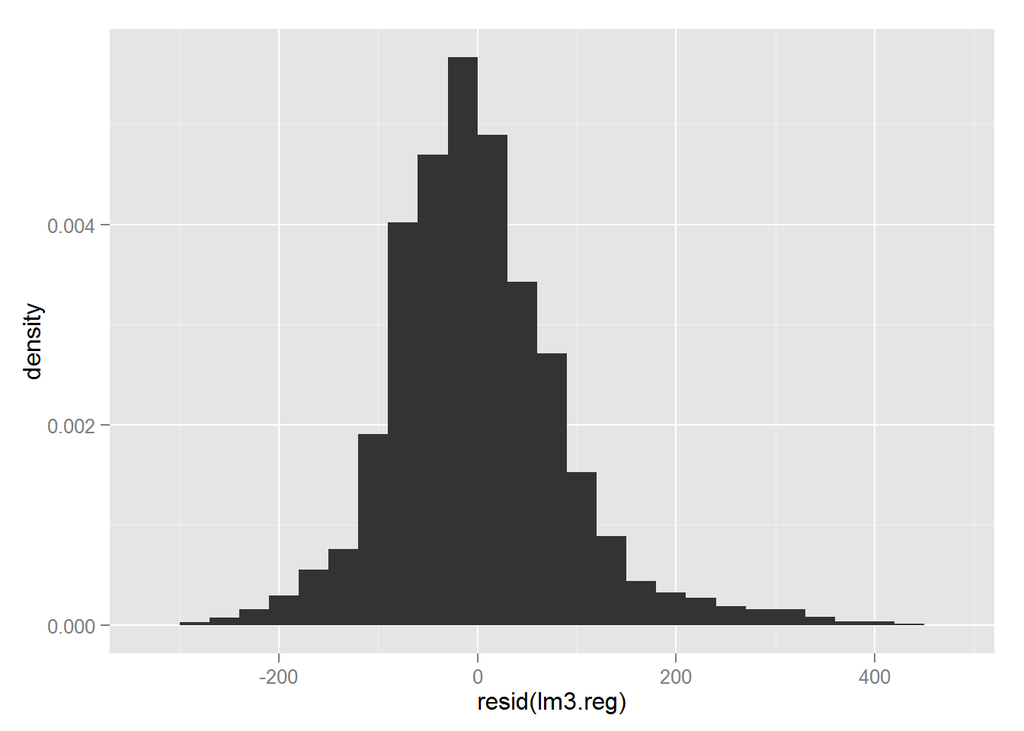

```r
ggplot() + aes(x = resid(lm3.reg)) + geom_histogram(aes(y = ..density..),binwidth = 30)
```

### Constant variance?

Plot residuals vs predicted values. The “fan out” pattern seen below suggests non-constant variance (heteroskedasticity).

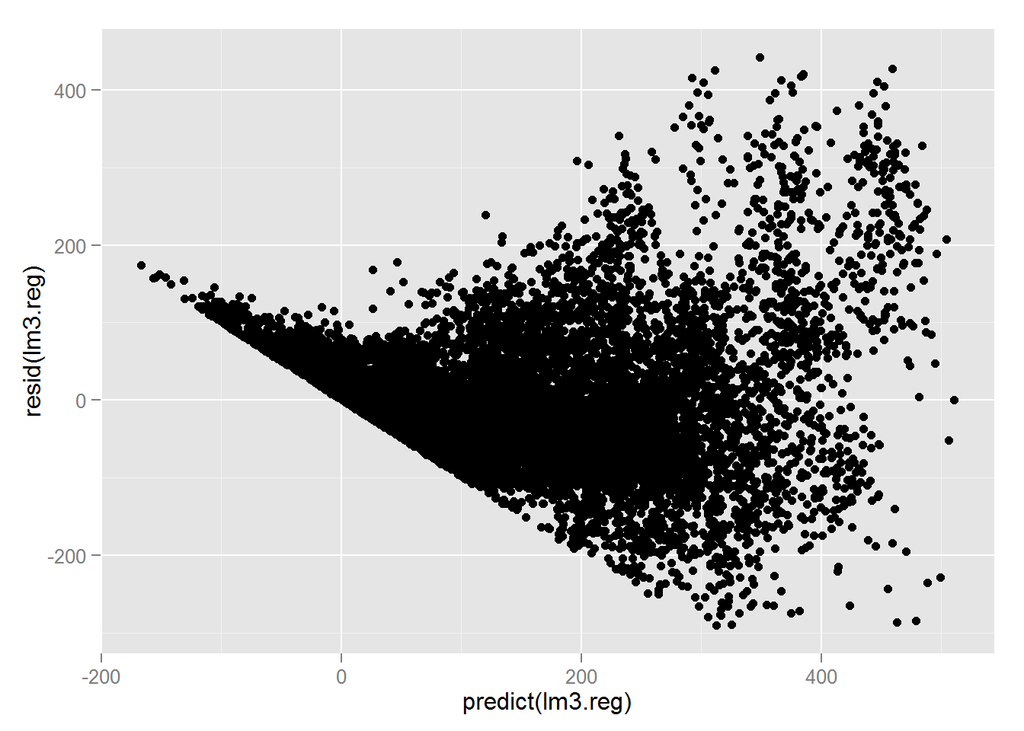

```r
ggplot() + aes(x = predict(lm3.reg), y = resid(lm3.reg)) + geom_point()
```

Of course, the actual Kaggle prediction problem for this contest is much more complex than this. We have to do predictions over time, only using data from before each forecasting epoch. That’s ok, our objective here was just to see how R can be used for data preparation and exploratory data analysis for an interesting dataset from a Kaggle competition.